# FDSeries: Computing Functional Diversity over Time in R

Simon P. Castillo, Felipe Opazo-Mella, Fabio A. Labra and Pablo A. Marquet

03 of May, 2021

## Summary

1. Functional diversity is increasingly described as an essential trait of ecosystem functioning; hence, its temporal analyses may provide a basis to understand past, present, and future trajectories of ecological assemblages. In this article, we present the package FDSeries for R, seeking to contribute with an open-source tool to study temporal patterns in functional diversity.
2. We developed a set of open-source functions, stored in FDSeries package, compatible with the platform R to analyse user’s records different temporal instances and compute functional diversity metrics. The package’s functions run over a data set containing the identification of functional traits at different time bins and abundance for each functional category.
3. The package allows quantifying different estimates of functional diversity, the visualisation of functional space and the contrast of the observed metrics against user-customised null models alongside with visualisations of basic plots of the temporal trajectories.
4. Extrinsic and intrinsic events leave a trace in the records of functional diversity and its relationship with ecosystem functioning. This package contributes to the quantification of functional diversity over a time series, allowing further studies of the functional dynamics of ecological communities and inferring how these may have responded to environmental changes.

## Preamble

The FDSeries package is located in an open repository; it can be downloaded and installed directly from R/Rstudio by using

```r
devtools::install_github("simonpcastillo/FDSeries", subdir="pkg")


#Or with the source packages

urlfrom <- "https://github.com/simonpcastillo/FDSeries/raw/master/FDSeries_0.1.0.tar.gz"
download.file(url=urlfrom, destfile = "FDSeries_0.1.0.tar.gz")
install.packages("FDSeries_0.1.0.tar.gz", repos = NULL, type="source")


#Then, loading it

library(FDSeries)
```

### Start here: Input data

To run the functions in this package, the user needs to have loaded a data frame of abundances for different life-modes or ecocodes for more than one-time bin. If the user has data only for one-time bin, the `FDSeries package` works in the same way that the `FD package`. There are two startings points and which of them the user will choose depends on what is the data he/she has. The first starting point considers that the user has a list of records of individuals at different time bins and their corresponding ecological features (ecocodes). In the package, we have added the dataset `data0` which represents a complitation of records to the level of genus (`View(data0)`). The second starting point considers that the user already has a dataframe with the estimation of occurrences for each ecocode over at east two time bins (`View(data1)`). If you have a dataset like `data0`, your strating point is the function 0 `Fd_rarefaction()`. Otherwise, if your dataset is like `data1`, your starting point is the function 1 `FD_df()`.

### Function 0 `FD_rarefaction()`

Note that to complete a sucessful analysis, the `data` must match the colnames exemplified by the package dataset `data0` (view (`names(data0)` or `View(data0)`)).

For example, using the dataset data0 in the package, the user can run

```r
FD_rarefaction(df = data0, times = 100)
```

### Function 1 `FD_df()`

Once we have an input data like `data1`, this function transforms it into a functional diversity dataframe `data2`.The function has two arguments:

- `df`: *dataframe*. Input dataframe with row names indicating time bins and column names indicating each life-mode or ecocode. The `df` values are estimates of the abundance of each life-mode at each time bin.
- `subcat`: *numeric vector*. The number of subcategories that each trait has. Its length must be equal that the number of traits of each life-mode.

To be clear, an ecocode is defined by a numeric sequence of traits as integers (e.g., 153), hence, the length of the `subcat` argument must be three and its values cannot be numerically lower than the respective values in the ecocode’s traits.

For example, using the package dataset we call the function defining the arguments as follows

```r
data2 <- FD_df(df=data1, subcat = c(6, 6, 6))

head(data1)
```

```
#>            111     115    261 266    311    312    315    321    322    324
#> -270.55 0.0000 10.5002 1.9364   0 0.4209 0.9531 0.1889 0.0000 0.4581 0.8169
#> -266.95 0.0000  8.2779 1.1165   0 0.3732 0.3857 0.2317 5.0112 5.4310 2.8344
#> -262.45 0.0000  2.0814 2.0708   0 1.1786 0.6955 0.0000 0.6648 4.2823 5.9083
#> -257.1  0.1334  9.3056 1.5605   0 0.8339 0.4937 0.3599 1.8926 8.0796 2.1219
#> -253.3  0.0000  8.4060 0.1980   0 0.7890 0.0000 1.6276 0.1892 4.9156 2.5069
#> -251.9  0.0000 22.5945 0.0000   0 0.0000 0.0000 2.9897 1.0563 1.5597 1.5343
#>            325    331 335    336    341     351 352    356      361 365 366
#> -270.55 0.3665 4.3202   0 0.2820 0.0903  5.8618   0 0.2515 131.5343   0   0
#> -266.95 0.9178 5.0435   0 0.4673 0.0753  5.0080   0 0.0000 100.8842   0   0
#> -262.45 2.8540 7.5305   0 0.9219 1.8390  5.6273   0 0.0000 102.6099   0   0
#> -257.1  2.3756 5.0468   0 0.3548 0.6650  6.7659   0 0.0000 125.1008   0   0
#> -253.3  2.4731 9.7987   0 0.1940 1.1490 10.3891   0 0.0000 110.5907   0   0
#> -251.9  0.2928 0.9671   0 0.0000 0.0000  3.8479   0 0.0000   3.6502   0   0
#>            422 431    441    451    461    525    531    532    533 535 536 541
#> -270.55 0.2681   0 1.6313 0.5086 0.6126 0.3222 1.5745 0.9093 0.2559   0   0   0
#> -266.95 0.0803   0 1.1148 0.7013 0.2788 1.1493 0.8768 1.8515 0.2870   0   0   0
#> -262.45 0.2666   0 1.7453 0.6730 0.3640 1.2363 1.8992 2.5364 0.6147   0   0   0
#> -257.1  0.8114   0 1.5120 0.1467 0.4967 1.6787 1.9930 1.0871 0.3573   0   0   0
#> -253.3  1.1866   0 1.5220 0.7531 0.0000 1.9677 3.6596 1.1092 0.4821   0   0   0
#> -251.9  0.0000   0 0.8339 0.0000 0.9489 0.9578 2.3147 0.6854 0.2991   0   0   0
#>            542    631 632    636    646
#> -270.55 0.0000 3.3870   0 0.0000 0.3240
#> -266.95 0.0794 6.2457   0 0.0000 0.1510
#> -262.45 0.1457 7.0260   0 0.0000 0.0000
#> -257.1  0.0000 1.6090   0 0.0708 0.1975
#> -253.3  0.0000 2.6772   0 0.1980 0.1949
#> -251.9  0.0000 0.0000   0 0.0000 0.0000
```

We create `data2` (a *dataframe*), a *functional diversity dataframe* (it is not a special object type, it is just to differentiate them). The dataframe `data2` is an extended version of `data1`, showing an extension of the functional traits for the next analyses.  
The next two functions allow us to quantify different measures associated to the functional diversity (Villéger, Mason, and Mouillot (2008)),; hence, to expound the temporal dynamics of multidimensional functional traits within a community.

## Empirical functional diversity estimates

### Function 2 `FD_Rao()`

One of the estimations used to characterise the functional diversity of a community is the Rao’s quadraic entropy (Rao (1982)). This functions calculates the Rao’s quadratic entropy, Simpson’s index and functional redundancy for each time bin along the temporal series. Its argument is

- `df`: *dataframe*. A functional diversity dataframe obtained by using the function `FD_df`.

```r
RaoSummary <- FD_Rao(df=data2)

head(RaoSummary)
```

```
#>            Time           Simpson            FunRao     FunRedundancy
#> -270.55 -270.55 0.378683859457612  0.18981696578351 0.188866893674102
#> -266.95 -266.95  0.53037712635285 0.260334101835751 0.270043024517099
#> -262.45 -262.45 0.550861548537347 0.262993881709145 0.287867666828202
#> -257.1   -257.1 0.480947800994248 0.237843550043117 0.243104250951131
#> -253.3   -253.3 0.548931004554903 0.265836754197044 0.283094250357859
#> -251.9   -251.9 0.716138117547658  0.38324588609151 0.332892231456147
```

This function returns a dataframe with the Rao’s complexity, Simpson’s diversity, and functional redundancy estimates calculated using the `SYNCSA::rao.diversity` function for each time bin.

### Function 3 `FD_metrics()`

This function computes other functional diversity metrics. This function is based on Villéger, Mason, and Mouillot (2008), and the code is an edited version of [Villeger’s code](http://villeger.sebastien.free.fr/Rscripts.html). Its argument is

- `df`: *dataframe*. A functional diversity dataframe obtained by using the function `FD_df`.

```r
FDSummary <- FD_metrics(df=data2)

head(FDSummary)
```

```
#>      time     FEve     FDiv             FSpe      FRic       chull_PC12
#> 1 -270.55 0.577572  0.98229 1.95243171254855 36.863141 13.1659113635074
#> 2 -266.95  0.59307 0.945219 1.93037543666628 36.748695 13.5068403229266
#> 3 -262.45 0.660154 0.920743 1.84046552568333 34.897932 13.8611645635014
#> 4  -257.1 0.562985 0.933646 1.92551216847947 36.093038 13.2835230628728
#> 5  -253.3 0.579267 0.946244 2.02539987579784 33.827874 12.9693920094878
#> 6  -251.9 0.717383 0.938177  2.2746897894888 24.232251 12.3279051677803
#>         chull_PC13
#> 1 11.0586207054292
#> 2 10.8930399202957
#> 3 11.5229219220032
#> 4 10.4942827558744
#> 5 10.2519857158861
#> 6 10.1657274752509
```

[output not shown]

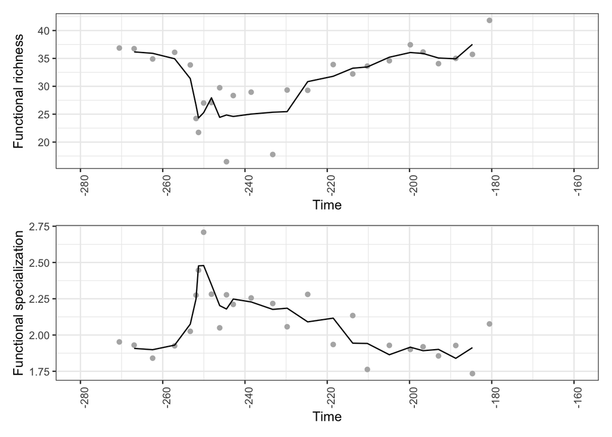

The function returns a dataframe `FDsummary`, which contains the estimated parameters for functional diversity for each time bin. `FEve` functional evenness, `FDiv` functional divergence, `FSpe` functional specialisation, and `FRic` functional richness. Also, several objects will be created in the global environment:

- `FuncSpace`: *list* to the Global Environment. Stores the functional space for each time bin.
- `ch1_list`: *list* to the Global Environment. Stores convex hull coordinates. Graphical use in `FD_plotPC`.
- `ch2_list`: *list* to the Global Environment. Stores convex hull coordinates. Graphical use in `FD_plotPC`.
- `pc1_list`: *list* to the Global Environment. Stores principal component coordinates. Graphical use in `FD_plotPC`.
- `pc2_list`: *list* to the Global Environment. Stores principal component coordinates. Graphical use in `FD_plotPC`.
- `pc3_list`: *list* to the Global Environment. Stores principal component coordinates. Graphical use in `FD_plotPC`.

### Function 4 `FD_plotRao()`

The next two functions allow to make simple plots (based on `ggplot2`) of the functional metrics (Simpson, Rao’s quadratic Entropy and Funcional redundancy) over time from empirical data calculated previously with `FD_Rao`. The arguments of the function are:

- `df`: dataframe obtained after running `FD_Rao`.
- `save.plot`: `TRUE` or `FALSE`. Default `TRUE`.
- `ext`: extension for the saved figures admitted by `ggplot2::ggsave` (e.g., `".png"`, `".svg"`). Default `".png"`.

```r
head(RaoSummary) # dataframe returned by DF_Rao
```

```
#>            Time           Simpson            FunRao     FunRedundancy
#> -270.55 -270.55 0.378683859457612  0.18981696578351 0.188866893674102
#> -266.95 -266.95  0.53037712635285 0.260334101835751 0.270043024517099
#> -262.45 -262.45 0.550861548537347 0.262993881709145 0.287867666828202
#> -257.1   -257.1 0.480947800994248 0.237843550043117 0.243104250951131
#> -253.3   -253.3 0.548931004554903 0.265836754197044 0.283094250357859
#> -251.9   -251.9 0.716138117547658  0.38324588609151 0.332892231456147
```

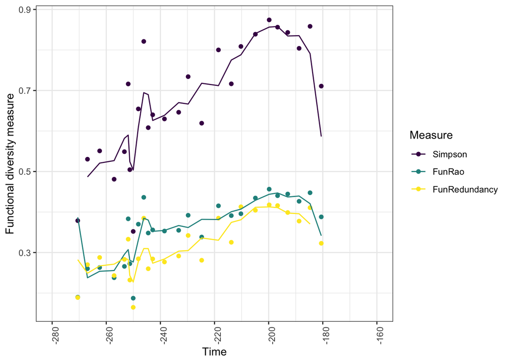

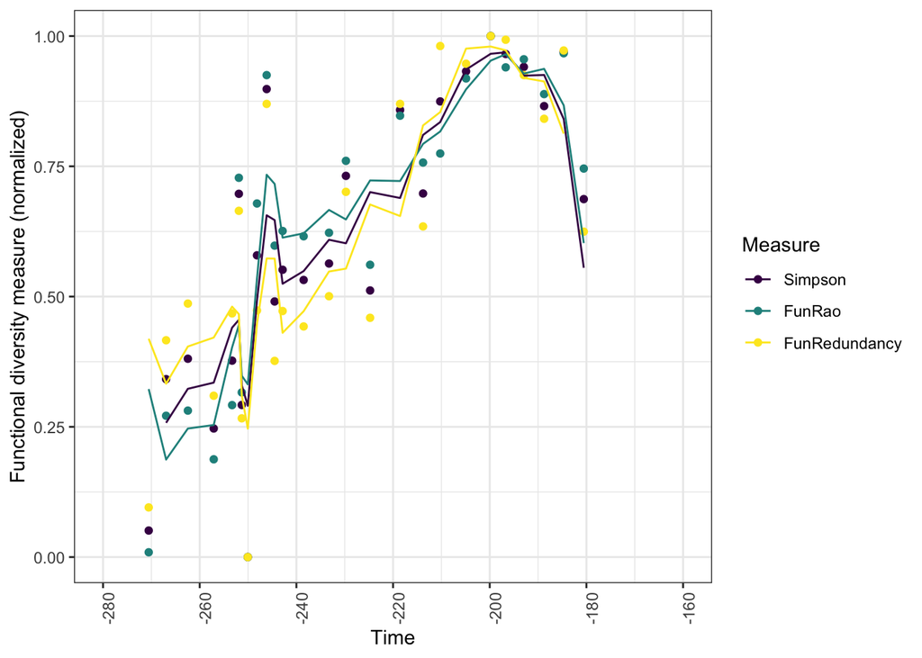

```r
FD_plotRao(RaoSummary, save.plot=FALSE, ext=".png")
```

This function returns two plots of Rao’s quadratic entropy, functional redundancy and Simpson’s richness estimates over time (raw and normalised). If `save.plot` is `TRUE`, the plots will be saved too. If the function is assigned it returns a list with two plots `plot1` and `plot2`, with the raw and normalised plots, respectively. The normalisation is performed within each variable according to its minimum and maximum values.  
The user can make their own plots with the dataframe returned by `FD_Rao`.

### Function 5 `FD_plotFS()`

Another method to visualise the functional diversity is by plotting the functional space. This function plots the functional space for each time bin as paired coordinates PC1 vs PC2 and PC1 vs PC3, where each point is a life-mode or ecocode and its size is proportional to its abundance at that time.  
The argumentsof this function are:

- `dfFD`: *dataframe*. A functional diversity dataframe created with the function `FD_df`.
- `sumRao`: *dataframe*. Empirical estimates obtained after running the function `FD_Rao`.
- `sumFD`: *dataframe*. Empirical estimates obtained after running the function `FD_metrics`.
- `plot.window`: `TRUE` or `FALSE` if the plots will appear in the Rstudio plot window. Default `TRUE`.
- `cols`: colour palette (e.g., `rainbow`, `viridis`, `plasma`). Default `viridis`.
- `save.plot`: `TRUE` or `FALSE.` Default `TRUE`.
- `add.labs`: `TRUE` or `FALSE.` It adds the label corresponding to each life-mode or ecocode. Default `FALSE`.
- `ext`: extension of the plot to be saved. Only an extension admitted by `ggplot2::ggsave` (e.g., `".svg"`, `".png"`). Default `".png"`.

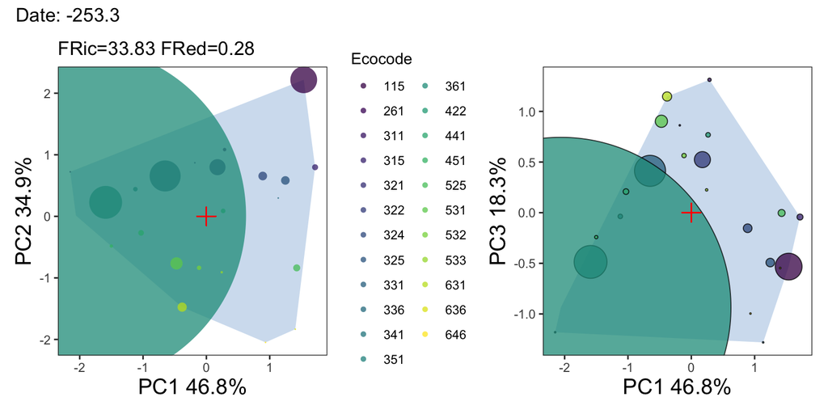

```r
FD_plotFS(dfFD=data2, sumRao=RaoSummary, sumFD=FDSummary, plot.window=FALSE, cols= viridis, save.plot= FALSE, add.labs=F, ext=".png" ) #plotsFS is a list

plot(plotsFS[[5]]) # to visualise the plot for the fifth time bin. 'plotsFS' is the list containing all the plots
```

The function returns a list named `plotsFS` with a plot for each time bin to your global environment. If `plot.window` is `TRUE` the plot will appear in the IDE plot window. If `save.plot` is `TRUE` plots will be saved with a `".png"` (by default) extension in your `wd`.